# Jacobian_Analysis slides

## Velocity Jacobian

## EE340: Robotics, IIT Dharwad

##### Designed, created and edited by Dr. Sangamesh Deepak

##### 11th of April, 2020 (During covid-19 epidemic lockdown)

## Single variable function

[interactive chart not shown]

$y = f(x)$

$y = f(x_0)+ \left(\dfrac{d f}{d x}\right)_{x=x_0} (x-x_0) + \cdots$

## Multivariable function

[interactive chart not shown]

$ \boldsymbol{x}= \begin{bmatrix} x_1 \\ x_2\\ \vdots \\ x_n \end{bmatrix}$ and $\boldsymbol{y}= \begin{bmatrix} y_1 \\ y_2\\ \vdots \\ y_m \end{bmatrix} $  
\begin{equation} \boldsymbol{y}=\boldsymbol{f}\left( \boldsymbol{x} \right) \end{equation} \begin{equation} \begin{bmatrix} y_1 \\ y_2\\ \vdots \\ y_m \end{bmatrix} = \begin{bmatrix} f_1\left( x_1, x_2, \cdots x_n \right)\\ f_2 \left( x_1, x_2, \cdots x_n \right)\\ \vdots \\ f_m \left( x_1, x_2, \cdots x_n \right) \end{bmatrix} \end{equation}

## Jacobian -- Derivative of Multivariable function

[interactive chart not shown]

\begin{equation} \boldsymbol{y} = \boldsymbol{f}(\boldsymbol{x}_0)+ \left(\dfrac{\boldsymbol{\partial f}}{\boldsymbol{\partial x}}\right)_{\boldsymbol{x}=\boldsymbol{x}_0} (\boldsymbol{x}-\boldsymbol{x}_0) + \cdots \end{equation}

\begin{equation} \dfrac{\boldsymbol{\partial f}}{\boldsymbol{\partial x}} = \begin{bmatrix} \dfrac{\partial f_1}{\partial x_1} & \dfrac{\partial f_1}{\partial x_2} & \cdots & \dfrac{\partial f_1}{\partial x_n} \\ \dfrac{\partial f_2}{\partial x_1} & \dfrac{\partial f_2}{\partial x_2} & \cdots & \dfrac{\partial f_2}{\partial x_n} \\ \vdots & \vdots & \ddots & \vdots \\ \dfrac{\partial f_m}{\partial x_1} & \dfrac{\partial f_m}{\partial x_2} & \cdots & \dfrac{\partial f_m}{\partial x_n} \end{bmatrix} \end{equation}

## Jacobian in total derivatives

[interactive chart not shown]

Let $\boldsymbol{\delta x} = (\boldsymbol{x}-\boldsymbol{x}_0)$ and $\boldsymbol{\delta y} = (\boldsymbol{y}-\boldsymbol{f}(\boldsymbol{x}_0))$

\begin{equation} \boldsymbol{\delta y} = \left(\dfrac{\boldsymbol{\partial f}}{\boldsymbol{\partial x}}\right)_{\boldsymbol{x}=\boldsymbol{x}_0} \boldsymbol{\delta x} + \cdots \end{equation}

\begin{equation} \boldsymbol{\dot{y}} = \left(\dfrac{\boldsymbol{\partial f}}{\boldsymbol{\partial x}}\right) \boldsymbol{\dot{x}} \end{equation}

[interactive chart not shown]

Let $\boldsymbol{a}_1$, $\boldsymbol{a}_2$, ... $\boldsymbol{a}_n$ be the columns of the Jacobian matrix, i.e.,

$ \boldsymbol{a}_1 = \begin{bmatrix} \dfrac{\partial f_1}{\partial x_1}\\ \dfrac{\partial f_2}{\partial x_1}\\ \vdots \\ \dfrac{\partial f_m}{\partial x_1} \end{bmatrix} $,

$\boldsymbol{a}_2 = \begin{bmatrix} \dfrac{\partial f_1}{\partial x_2}\\ \dfrac{\partial f_2}{\partial x_2}\\ \vdots \\ \dfrac{\partial f_m}{\partial x_2} \end{bmatrix}$, ... $\boldsymbol{a}_n = \begin{bmatrix} \dfrac{\partial f_1}{\partial x_n}\\ \dfrac{\partial f_2}{\partial x_n}\\ \vdots \\ \dfrac{\partial f_m}{\partial x_n} \end{bmatrix} $

\begin{equation} \boldsymbol{\dot{y}} = \boldsymbol{a}_{1} \dot{x}_1 + \boldsymbol{a}_{2} \dot{x}_2 + \cdots \boldsymbol{a}_{n} \dot{x}_n \end{equation}

### Observation: If we already have the expression for total (time) derivative of the multivariable function, then the columns of the Jacobian Matrix are the coefficients of time derivatives of the independent variables </font>

## Jacobian in this lesson

[interactive chart not shown]

</div> $ \boldsymbol{\dot{y}} = \begin{bmatrix} {}^{0}\boldsymbol{v}_{L} \\ {}^{0}\boldsymbol{\omega}_{L} \end{bmatrix} $ and $\boldsymbol{\dot{x}}$ is matrix of joint variable derivatives

[interactive chart not shown]

### Note: This is a long slide. Scroll below to see contents.

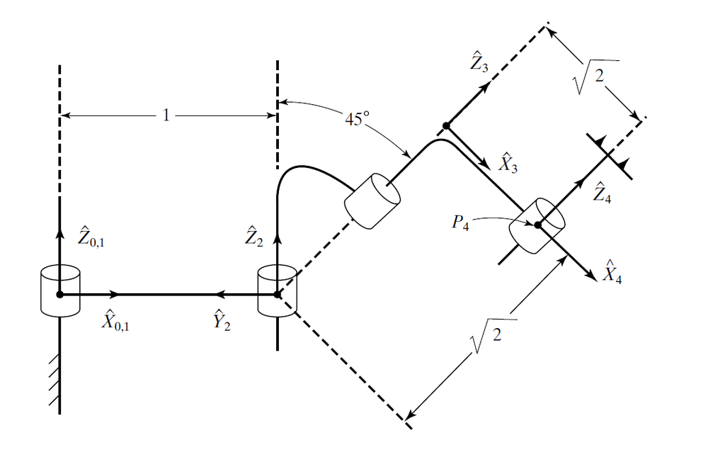

```python
# Created by Dr. Sangamesh Deepak R to teach Robotics online during covid 19 outbreak

import sympy as sy
import numpy as np
sy.init_printing()
```

```python
# Link parameters
a1 = 1
a2 = 0
a3 = sy.sqrt(2)

alpha1 = 0
alpha2 = sy.pi/4
alpha3 = 0
```

```python
# Joint parameters

theta1 = sy.Symbol(r'\theta_1')
theta2 = sy.Symbol(r'\theta_2')
theta3 = sy.Symbol(r'\theta_3')
theta4 = sy.Symbol(r'\theta_4')

d1 = 0
d2 = 0
d3 = sy.sqrt(2)
d4 = 0
```

```python
temp1 = 34.567
temp2 = np.pi/4
temp3 = sy.Symbol(r'\mu_k')
temp4 = sy.pi/4
[temp1, temp2, temp3, temp4]
```

$\displaystyle \left[ 34.567, \ 0.7853981633974483, \ \mu_k, \ \frac{\pi}{4}\right]$

```python
temp5 = sy.expand((temp3+temp4)**2)
temp6 = sy.expand((temp3+temp2)**2)
temp7 = sy.expand((temp1+temp2)**2)
[temp5, temp6, temp7]
```

$\displaystyle \left[ \mu_k^{2} + \frac{\pi \mu_k}{2} + \frac{\pi^{2}}{16}, \ \mu_k^{2} + 1.5707963267949 \mu_k + 0.616850275068085, \ 1249.79205590339\right]$

```python
# transformation from of i' frame with respect to i frame

def link_transform(a_i, alpha_i):
    Link_T = sy.Matrix([[1, 0, 0, a_i], [0, sy.cos(alpha_i), -sy.sin(alpha_i), 0], [0, sy.sin(alpha_i), sy.cos(alpha_i), 0], \
                   [0,0,0,1] ])
    return Link_T
```

```python
# transformation of i frame with respect to (i-1)' frame'
def joint_transform(d_i, theta_i):
    Joint_T = sy.Matrix([[sy.cos(theta_i),  -sy.sin(theta_i), 0, 0],
                        [sy.sin(theta_i),  sy.cos(theta_i), 0, 0],
                        [0, 0, 1, d_i],
                        [0,0,0,1] ])
    return Joint_T
```

```python
# Computation of transformation matricies of different link frames with respect to the ground frame
T_0 = sy.Identity(4)
T_0_1 = joint_transform(d1, theta1)


T_1_2 = sy.trigsimp( link_transform(a1, alpha1)*joint_transform(d2, theta2) )
T_0_2 = sy.trigsimp( T_0_1* T_1_2);

T_2_3 = sy.trigsimp(link_transform(a2, alpha2)*joint_transform(d3, theta3) )
T_0_3 = sy.trigsimp( T_0_2* T_2_3);

T_3_4 = sy.trigsimp(link_transform(a3, alpha3)*joint_transform(d4, theta4) )
T_0_4 = sy.trigsimp( T_0_3* T_3_4);
```

```python
T_0_1, T_0_2, T_0_3, T_0_4 # Transformation matricies of first, second, third and fourth bodies
```

[output not shown]

```python
T_0_4[2,3]   # (3,4)th element of trnasformation matrix for 4 frame
```

$\displaystyle \sin{\left(\theta_3 \right)} + 1$

```python
# Extraction of Rotation matrices
R_0_1= T_0_1[0:3,0:3]
R_1_2= T_1_2[0:3,0:3]
R_2_3= T_2_3[0:3,0:3]
R_3_4= T_3_4[0:3,0:3]

r_0_1=T_0_1[0:3,3]
r_1_2=T_1_2[0:3,3]
r_2_3=T_2_3[0:3,3]
r_3_4=T_3_4[0:3,3]
```

```python
 def cross_product(a,b):
        c=sy.Matrix([
            [a[1,0]*b[2,0]-a[2,0]*b[1,0]],
            [a[2,0]*b[0,0]-a[0,0]*b[2,0]],
            [a[0,0]*b[1,0]-a[1,0]*b[0,0]]
            ])
        return c
```

```python
m=sy.Matrix([[0],[0],[1]])
n=sy.Matrix([[1],[0],[0]])
p = cross_product(m,n)
p
```

$\displaystyle \left[\begin{matrix}0\\1\\0\end{matrix}\right]$

```python
d_d1=0
d_d2=0
d_d3=0
d_d4=0

d_theta1 = sy.Symbol(r'\dot{\theta}_1')
d_theta2 = sy.Symbol(r'\dot{\theta}_2')
d_theta3 = sy.Symbol(r'\dot{\theta}_3')
d_theta4 = sy.Symbol(r'\dot{\theta}_4')

d_d1, d_d2, d_d3, d_d4, d_theta1, d_theta2, d_theta3, d_theta4
```

$\displaystyle \left( 0, \ 0, \ 0, \ 0, \ \dot{\theta}_1, \ \dot{\theta}_2, \ \dot{\theta}_3, \ \dot{\theta}_4\right)$

```python
omega_0_0 = sy.Matrix([[0],[0],[0]])
v_0_0 = sy.Matrix([[0],[0],[0]])
```

```python
omega_1_1= R_0_1.T*(omega_0_0)+sy.Matrix([[0],[0],[d_theta1] ])

v_1_1 = R_0_1.T*(v_0_0 + cross_product(omega_0_0,r_0_1))+sy.Matrix([[0],[0],[d_d1] ])

omega_1_1, v_1_1
```

$\displaystyle \left( \left[\begin{matrix}0\\0\\\dot{\theta}_1\end{matrix}\right], \ \left[\begin{matrix}0\\0\\0\end{matrix}\right]\right)$

```python
omega_2_2= R_1_2.T*(omega_1_1)+sy.Matrix([[0],[0],[d_theta2] ])

v_2_2 = R_1_2.T*(v_1_1 + cross_product(omega_1_1,r_1_2))+sy.Matrix([[0],[0],[d_d2] ])

omega_2_2, v_2_2
```

$\displaystyle \left( \left[\begin{matrix}0\\0\\\dot{\theta}_1 + \dot{\theta}_2\end{matrix}\right], \ \left[\begin{matrix}\dot{\theta}_1 \sin{\left(\theta_2 \right)}\\\dot{\theta}_1 \cos{\left(\theta_2 \right)}\\0\end{matrix}\right]\right)$

```python
omega_3_3= R_2_3.T*(omega_2_2)+sy.Matrix([[0],[0],[d_theta3] ])

v_3_3 = R_2_3.T*(v_2_2 + cross_product(omega_2_2,r_2_3))+sy.Matrix([[0],[0],[d_d3] ])

omega_3_3, v_3_3
```

$\displaystyle \left( \left[\begin{matrix}\frac{\sqrt{2} \left(\dot{\theta}_1 + \dot{\theta}_2\right) \sin{\left(\theta_3 \right)}}{2}\\\frac{\sqrt{2} \left(\dot{\theta}_1 + \dot{\theta}_2\right) \cos{\left(\theta_3 \right)}}{2}\\\dot{\theta}_3 + \frac{\sqrt{2} \left(\dot{\theta}_1 + \dot{\theta}_2\right)}{2}\end{matrix}\right], \ \left[\begin{matrix}\frac{\sqrt{2} \dot{\theta}_1 \sin{\left(\theta_3 \right)} \cos{\left(\theta_2 \right)}}{2} + \left(\dot{\theta}_1 \sin{\left(\theta_2 \right)} + \dot{\theta}_1 + \dot{\theta}_2\right) \cos{\left(\theta_3 \right)}\\\frac{\sqrt{2} \dot{\theta}_1 \cos{\left(\theta_2 \right)} \cos{\left(\theta_3 \right)}}{2} - \left(\dot{\theta}_1 \sin{\left(\theta_2 \right)} + \dot{\theta}_1 + \dot{\theta}_2\right) \sin{\left(\theta_3 \right)}\\- \frac{\sqrt{2} \dot{\theta}_1 \cos{\left(\theta_2 \right)}}{2}\end{matrix}\right]\right)$

```python
omega_4_4= R_3_4.T*(omega_3_3)+sy.Matrix([[0],[0],[d_theta4] ])

v_4_4 = R_3_4.T*(v_3_3 + cross_product(omega_3_3,r_3_4))+sy.Matrix([[0],[0],[d_d4] ])

omega_4_4, v_4_4
```

$\displaystyle \left( \left[\begin{matrix}\frac{\sqrt{2} \left(\dot{\theta}_1 + \dot{\theta}_2\right) \sin{\left(\theta_3 \right)} \cos{\left(\theta_4 \right)}}{2} + \frac{\sqrt{2} \left(\dot{\theta}_1 + \dot{\theta}_2\right) \sin{\left(\theta_4 \right)} \cos{\left(\theta_3 \right)}}{2}\\- \frac{\sqrt{2} \left(\dot{\theta}_1 + \dot{\theta}_2\right) \sin{\left(\theta_3 \right)} \sin{\left(\theta_4 \right)}}{2} + \frac{\sqrt{2} \left(\dot{\theta}_1 + \dot{\theta}_2\right) \cos{\left(\theta_3 \right)} \cos{\left(\theta_4 \right)}}{2}\\\dot{\theta}_3 + \dot{\theta}_4 + \frac{\sqrt{2} \left(\dot{\theta}_1 + \dot{\theta}_2\right)}{2}\end{matrix}\right], \ \left[\begin{matrix}\left(\frac{\sqrt{2} \dot{\theta}_1 \sin{\left(\theta_3 \right)} \cos{\left(\theta_2 \right)}}{2} + \left(\dot{\theta}_1 \sin{\left(\theta_2 \right)} + \dot{\theta}_1 + \dot{\theta}_2\right) \cos{\left(\theta_3 \right)}\right) \cos{\left(\theta_4 \right)} + \left(\frac{\sqrt{2} \dot{\theta}_1 \cos{\left(\theta_2 \right)} \cos{\left(\theta_3 \right)}}{2} + \sqrt{2} \left(\dot{\theta}_3 + \frac{\sqrt{2} \left(\dot{\theta}_1 + \dot{\theta}_2\right)}{2}\right) - \left(\dot{\theta}_1 \sin{\left(\theta_2 \right)} + \dot{\theta}_1 + \dot{\theta}_2\right) \sin{\left(\theta_3 \right)}\right) \sin{\left(\theta_4 \right)}\\- \left(\frac{\sqrt{2} \dot{\theta}_1 \sin{\left(\theta_3 \right)} \cos{\left(\theta_2 \right)}}{2} + \left(\dot{\theta}_1 \sin{\left(\theta_2 \right)} + \dot{\theta}_1 + \dot{\theta}_2\right) \cos{\left(\theta_3 \right)}\right) \sin{\left(\theta_4 \right)} + \left(\frac{\sqrt{2} \dot{\theta}_1 \cos{\left(\theta_2 \right)} \cos{\left(\theta_3 \right)}}{2} + \sqrt{2} \left(\dot{\theta}_3 + \frac{\sqrt{2} \left(\dot{\theta}_1 + \dot{\theta}_2\right)}{2}\right) - \left(\dot{\theta}_1 \sin{\left(\theta_2 \right)} + \dot{\theta}_1 + \dot{\theta}_2\right) \sin{\left(\theta_3 \right)}\right) \cos{\left(\theta_4 \right)}\\- \frac{\sqrt{2} \dot{\theta}_1 \cos{\left(\theta_2 \right)}}{2} - \left(\dot{\theta}_1 + \dot{\theta}_2\right) \cos{\left(\theta_3 \right)}\end{matrix}\right]\right)$

The following steps are carried out below:

1. Extraction of $\boldsymbol{R}_{4}^{0}$ from $\boldsymbol{T}_{4}^{0}$
2. $\boldsymbol{v}_{4}^{0} = \boldsymbol{R}_{4}^{0} \boldsymbol{v}_{4}^{4}$
3. $\boldsymbol{\omega}_{4}^{0} = \boldsymbol{R}_{4}^{0} \boldsymbol{\omega}_{4}^{4}$

```python
R_0_4= T_0_4[0:3,0:3]
v_0_4=sy.trigsimp(R_0_4*v_4_4)
omega_0_4 = sy.trigsimp(R_0_4*omega_4_4)
```

The following steps are carried out below:

1. $^{0}\boldsymbol{v}_{4}$ and $^{0}\boldsymbol{\omega}_{4}$ are stacked one below the other in the form of column matrix of size $6 \times 1$: $^{0}\boldsymbol{\mu}_{4} = \begin{bmatrix} ^{0}\boldsymbol{v}_{4} \\ ^{0} \boldsymbol{\omega}_{4} \end{bmatrix}$

```python
mu_0_4 = sy.Matrix([v_0_4, omega_0_4])
mu_0_4
```

$\displaystyle \left[\begin{matrix}- \dot{\theta}_1 \sin{\left(\theta_1 \right)} - \dot{\theta}_1 \sin{\left(\theta_3 \right)} \cos{\left(\theta_1 + \theta_2 \right)} - \sqrt{2} \dot{\theta}_1 \sin{\left(\theta_1 + \theta_2 \right)} \cos{\left(\theta_3 \right)} + \dot{\theta}_1 \cos{\left(\theta_1 + \theta_2 \right)} - \dot{\theta}_2 \sin{\left(\theta_3 \right)} \cos{\left(\theta_1 + \theta_2 \right)} - \sqrt{2} \dot{\theta}_2 \sin{\left(\theta_1 + \theta_2 \right)} \cos{\left(\theta_3 \right)} + \dot{\theta}_2 \cos{\left(\theta_1 + \theta_2 \right)} - \sqrt{2} \dot{\theta}_3 \sin{\left(\theta_3 \right)} \cos{\left(\theta_1 + \theta_2 \right)} - \dot{\theta}_3 \sin{\left(\theta_1 + \theta_2 \right)} \cos{\left(\theta_3 \right)}\\- \dot{\theta}_1 \sin{\left(\theta_3 \right)} \sin{\left(\theta_1 + \theta_2 \right)} + \dot{\theta}_1 \sin{\left(\theta_1 + \theta_2 \right)} + \dot{\theta}_1 \cos{\left(\theta_1 \right)} + \sqrt{2} \dot{\theta}_1 \cos{\left(\theta_3 \right)} \cos{\left(\theta_1 + \theta_2 \right)} - \dot{\theta}_2 \sin{\left(\theta_3 \right)} \sin{\left(\theta_1 + \theta_2 \right)} + \dot{\theta}_2 \sin{\left(\theta_1 + \theta_2 \right)} + \sqrt{2} \dot{\theta}_2 \cos{\left(\theta_3 \right)} \cos{\left(\theta_1 + \theta_2 \right)} - \sqrt{2} \dot{\theta}_3 \sin{\left(\theta_3 \right)} \sin{\left(\theta_1 + \theta_2 \right)} + \dot{\theta}_3 \cos{\left(\theta_3 \right)} \cos{\left(\theta_1 + \theta_2 \right)}\\\dot{\theta}_3 \cos{\left(\theta_3 \right)}\\\frac{\sqrt{2} \left(\dot{\theta}_3 + \dot{\theta}_4\right) \sin{\left(\theta_1 + \theta_2 \right)}}{2}\\- \frac{\sqrt{2} \left(\dot{\theta}_3 + \dot{\theta}_4\right) \cos{\left(\theta_1 + \theta_2 \right)}}{2}\\\dot{\theta}_1 + \dot{\theta}_2 + \frac{\sqrt{2} \dot{\theta}_3}{2} + \frac{\sqrt{2} \dot{\theta}_4}{2}\end{matrix}\right]$

### Extraction of the coefficients of joint variable derivatives

In the expression of $^{0}\boldsymbol{\mu}_{4}$, $\theta_1$ is set to one and rest of the joint variables is set to zero. THis give the coefficient matrix $\boldsymbol{a}_{1}$. Similarly $\boldsymbol{a}_{2}$, $\boldsymbol{a}_{3}$ and $\boldsymbol{a}_{4}$ are obtained.

```python
a1= mu_0_4.subs([(d_theta1, 1), (d_theta2,0), (d_theta3, 0), (d_theta4,0)])
a2= mu_0_4.subs([(d_theta1, 0), (d_theta2,1), (d_theta3, 0), (d_theta4,0)])
a3= mu_0_4.subs([(d_theta1, 0), (d_theta2,0), (d_theta3, 1), (d_theta4,0)])
a4= mu_0_4.subs([(d_theta1, 0), (d_theta2,0), (d_theta3, 0), (d_theta4,1)])
```

```python
a1
```

$\displaystyle \left[\begin{matrix}- \sin{\left(\theta_1 \right)} - \sin{\left(\theta_3 \right)} \cos{\left(\theta_1 + \theta_2 \right)} - \sqrt{2} \sin{\left(\theta_1 + \theta_2 \right)} \cos{\left(\theta_3 \right)} + \cos{\left(\theta_1 + \theta_2 \right)}\\- \sin{\left(\theta_3 \right)} \sin{\left(\theta_1 + \theta_2 \right)} + \sin{\left(\theta_1 + \theta_2 \right)} + \cos{\left(\theta_1 \right)} + \sqrt{2} \cos{\left(\theta_3 \right)} \cos{\left(\theta_1 + \theta_2 \right)}\\0\\0\\0\\1\end{matrix}\right]$

$\boldsymbol{a}_{1}$, $\boldsymbol{a}_{2}$, $\boldsymbol{a}_{3}$, and $\boldsymbol{a}_{4}$ are stacked horizontally to form the Jacobian matrix ${}^{0}\boldsymbol{J}_{4} = \begin{bmatrix} \boldsymbol{a}_1 & \boldsymbol{a}_2 & \boldsymbol{a}_3 & \boldsymbol{a}_4 \end{bmatrix} $

```python
J=a1
J=J.col_insert(1,a2)
J=J.col_insert(2,a3)
J=J.col_insert(3,a4)
J
```

$\displaystyle \left[\begin{matrix}- \sin{\left(\theta_1 \right)} - \sin{\left(\theta_3 \right)} \cos{\left(\theta_1 + \theta_2 \right)} - \sqrt{2} \sin{\left(\theta_1 + \theta_2 \right)} \cos{\left(\theta_3 \right)} + \cos{\left(\theta_1 + \theta_2 \right)} & - \sin{\left(\theta_3 \right)} \cos{\left(\theta_1 + \theta_2 \right)} - \sqrt{2} \sin{\left(\theta_1 + \theta_2 \right)} \cos{\left(\theta_3 \right)} + \cos{\left(\theta_1 + \theta_2 \right)} & - \sqrt{2} \sin{\left(\theta_3 \right)} \cos{\left(\theta_1 + \theta_2 \right)} - \sin{\left(\theta_1 + \theta_2 \right)} \cos{\left(\theta_3 \right)} & 0\\- \sin{\left(\theta_3 \right)} \sin{\left(\theta_1 + \theta_2 \right)} + \sin{\left(\theta_1 + \theta_2 \right)} + \cos{\left(\theta_1 \right)} + \sqrt{2} \cos{\left(\theta_3 \right)} \cos{\left(\theta_1 + \theta_2 \right)} & - \sin{\left(\theta_3 \right)} \sin{\left(\theta_1 + \theta_2 \right)} + \sin{\left(\theta_1 + \theta_2 \right)} + \sqrt{2} \cos{\left(\theta_3 \right)} \cos{\left(\theta_1 + \theta_2 \right)} & - \sqrt{2} \sin{\left(\theta_3 \right)} \sin{\left(\theta_1 + \theta_2 \right)} + \cos{\left(\theta_3 \right)} \cos{\left(\theta_1 + \theta_2 \right)} & 0\\0 & 0 & \cos{\left(\theta_3 \right)} & 0\\0 & 0 & \frac{\sqrt{2} \sin{\left(\theta_1 + \theta_2 \right)}}{2} & \frac{\sqrt{2} \sin{\left(\theta_1 + \theta_2 \right)}}{2}\\0 & 0 & - \frac{\sqrt{2} \cos{\left(\theta_1 + \theta_2 \right)}}{2} & - \frac{\sqrt{2} \cos{\left(\theta_1 + \theta_2 \right)}}{2}\\1 & 1 & \frac{\sqrt{2}}{2} & \frac{\sqrt{2}}{2}\end{matrix}\right]$

## What is the use of the Jacobian Matrix. What insights does it offer?

Let us find the numerical value of the Jacobian at a particular configuration: $\theta_1=0$, $\theta_2 = \dfrac{\pi}{2}$, $\theta_3 = -\dfrac{\pi}{2}$, $\theta_4 = 0$.

```python
J_num_1 = J.subs([(theta1, 0), (theta2, sy.pi/2), (theta3, -sy.pi/2), (theta4,0)])
J_num_1
```

$\displaystyle \left[\begin{matrix}0 & 0 & 0 & 0\\3 & 2 & \sqrt{2} & 0\\0 & 0 & 0 & 0\\0 & 0 & \frac{\sqrt{2}}{2} & \frac{\sqrt{2}}{2}\\0 & 0 & 0 & 0\\1 & 1 & \frac{\sqrt{2}}{2} & \frac{\sqrt{2}}{2}\end{matrix}\right]$

The way we can relate the Jacobian Matrix with the actual robot motion is decribed in the two videos below:

## Part 1

```python
from IPython.display import YouTubeVideo

YouTubeVideo('kUr9xYbJrH4')
```

[video not shown]

# Part 2

```python
YouTubeVideo('Y0zoIl7sOdU')
```

[video not shown]

# A brief review of rank of a matrix and its significance

Consider the matrix equation \begin{equation} \boldsymbol{b} = \boldsymbol{M} \boldsymbol{a} \end{equation}

- Further suppose that $\boldsymbol{b}$ represents velocity of a point with the three elements of the matrix reprsenting $x$, $y$ and $z$ components.
- Any value of $\boldsymbol{b}$ can be represented as a point in a cartesian coordinate system with $x$, $y$, $z$ axes representing $x$, $y$ and $z$ components of velocity
- We can also think of $\boldsymbol{b}$ as a vector which starts from the origin and ends at the point
- Let $\boldsymbol{M} = \begin{bmatrix} 1 \\ 2 \\ 3 \end{bmatrix}$, and $\boldsymbol{a} = \begin{bmatrix} \alpha_1 \end{bmatrix} $
- Assume that $\alpha_1$ can take any real value.
- If we consider the set of all possible values for $\boldsymbol{b}$ and plot them in a cartesian velocity graph, the plot would be a one dimensional straight line.
- Let $\boldsymbol{M} = \begin{bmatrix} 1 & 2 \\ 2 & 3 \\ 3 & 4 \end{bmatrix}$, and $\boldsymbol{a} = \begin{bmatrix} \alpha_1 \\ \alpha_2 \end{bmatrix} $
- Assume that $\alpha_1$ and $\alpha_2$ can take any real value.
- If we consider the set of all possible values for $\boldsymbol{b}$ and plot them in a cartesion velocity graph, what would be dimension of the plot? Is it one dimensional or two dimensional?
- To answer the question, let us plot the vectors corrsponding to the columns of the matrix

```python
from IPython.display import IFrame

IFrame(src='./two_vectors.html', width=700, height=600)
```

[interactive chart not shown]

- From the plot we see that the two vectors are distinct.
- The set of all possibilities for $\boldsymbol{b}$ would be a plane containing these two vectors.
- The plane is two dimensional
- Hence the set of possibilities is two dimesnional.
- $\boldsymbol{b}$ can have any direction along the plane.
- The motion abilities or manouverability in second case is higher compared to first case.
- In first case velocity or small motion could be only along a particular direction.
- In the second case velocity or small motion could be along any direction in the plane.
- The dimension of the possibilities of $\boldsymbol{b}$ indicates the degree of maneuverability for small motion.
- In a general system $\boldsymbol{b} = \boldsymbol{M} \boldsymbol{a}$, what linear algebraic quantity indicates the dimension of possibilities of $\boldsymbol{b}$.
- Is it number of columns of $\boldsymbol{M}$?
- No, it is the rank of $\boldsymbol{M}$ that indicates the dimension of possibilities of $\boldsymbol{b}$.
- How do you find rank of a matrix?
- From first principle, you could find rank from row-reduced echelon form which you might have studied in a maths course.
- Here we will see how to find the rank using sympy python library.
- We find what is called as column space of the matrix with sympy.
- The number of columns in columnspace is the rank. An illustrative example is given next.

```python
M = sy.Matrix([[1, 1, 2], [2 ,1 , 3], [3 , 1, 4]])
M
```

$\displaystyle \left[\begin{matrix}1 & 1 & 2\\2 & 1 & 3\\3 & 1 & 4\end{matrix}\right]$

```python
M.columnspace()
```

$\displaystyle \left[ \left[\begin{matrix}1\\2\\3\end{matrix}\right], \ \left[\begin{matrix}1\\1\\1\end{matrix}\right]\right]$

The number of column space has turned out to be two. Hence the rank is two.

# Rank of Jacobian Matrix

- Similar to the example of previous slides, in equation $\begin{bmatrix} ^{0}\boldsymbol{v}_{4} \\ ^{0} \boldsymbol{\omega}_{4} \end{bmatrix}={}^{0}\boldsymbol{J}_{4} \begin{bmatrix} \dot{\theta}_{1} \\ \dot{\theta}_{2}\\ \dot{\theta}_{3} \\ \dot{\theta}_{4} \end{bmatrix}$, the dimension of possibilities for $\begin{bmatrix} ^{0}\boldsymbol{v}_{4} \\ ^{0} \boldsymbol{\omega}_{4} \end{bmatrix}$ is given by the rank of ${}^{0}\boldsymbol{J}_{4}$.
- Since $\begin{bmatrix} ^{0}\boldsymbol{v}_{4} \\ ^{0} \boldsymbol{\omega}_{4} \end{bmatrix}$ indicates linear and angular velocity of last frame, the rank ${}^{0}\boldsymbol{J}_{4}$ would also indicate the degree of maneuverability of last frame in both position and orientation.

### If we want the robot to have high maneuverability, we should operate the robot in such configurations where the rank of Jacobian Matrix is high.

### Can rank of Jacobian matrix vary from configuration to configuration?

Let us consider two distinct configurations :

1. ($\theta_1 = 0$, $\theta_2 = +\dfrac{\pi}{2}$, $\theta_3 = -\dfrac{\pi}{2}$, $\theta_4 =0 $ )
2. ($\theta_1 = 0$, $\theta_2 = +\dfrac{\pi}{2}$, $\theta_3 = 0$, $\theta_4 =0 $ )

Let us

1. evaluate the jacobian corresponding to them

```python
J_num_1 = J.subs([(theta1, 0), (theta2, sy.pi/2), (theta3, -sy.pi/2), (theta4,0)])
J_num_2 = J.subs([(theta1, 0), (theta2, sy.pi/2), (theta3, 0), (theta4,0)])
display([J_num_1, J_num_2])
display([J_num_1.columnspace(), J_num_2.columnspace()])
```

$\displaystyle \left[ \left[\begin{matrix}0 & 0 & 0 & 0\\3 & 2 & \sqrt{2} & 0\\0 & 0 & 0 & 0\\0 & 0 & \frac{\sqrt{2}}{2} & \frac{\sqrt{2}}{2}\\0 & 0 & 0 & 0\\1 & 1 & \frac{\sqrt{2}}{2} & \frac{\sqrt{2}}{2}\end{matrix}\right], \ \left[\begin{matrix}- \sqrt{2} & - \sqrt{2} & -1 & 0\\2 & 1 & 0 & 0\\0 & 0 & 1 & 0\\0 & 0 & \frac{\sqrt{2}}{2} & \frac{\sqrt{2}}{2}\\0 & 0 & 0 & 0\\1 & 1 & \frac{\sqrt{2}}{2} & \frac{\sqrt{2}}{2}\end{matrix}\right]\right]$

$\displaystyle \left[ \left[ \left[\begin{matrix}0\\3\\0\\0\\0\\1\end{matrix}\right], \ \left[\begin{matrix}0\\2\\0\\0\\0\\1\end{matrix}\right], \ \left[\begin{matrix}0\\\sqrt{2}\\0\\\frac{\sqrt{2}}{2}\\0\\\frac{\sqrt{2}}{2}\end{matrix}\right]\right], \ \left[ \left[\begin{matrix}- \sqrt{2}\\2\\0\\0\\0\\1\end{matrix}\right], \ \left[\begin{matrix}- \sqrt{2}\\1\\0\\0\\0\\1\end{matrix}\right], \ \left[\begin{matrix}-1\\0\\1\\\frac{\sqrt{2}}{2}\\0\\\frac{\sqrt{2}}{2}\end{matrix}\right], \ \left[\begin{matrix}0\\0\\0\\\frac{\sqrt{2}}{2}\\0\\\frac{\sqrt{2}}{2}\end{matrix}\right]\right]\right]$

- The column space of the first jacobian has three column matricies
- The column space of the second jacobian has four column matricies
- The rank of Jacobian at the first configuration is three
- The rank of Jacobian at second configuration is four.
- Indeed rank of Jacobian can vary from configuration to configuration
- The robot has higher degree of maneuverability in the second configuration
- Is there any other configuration where degree of maneuverability (rank of Jacobian) is higher than that of second configuration? No. The rank of a matrix cannot exceed number of rows and number of columns.

## Relation of rank of Jacobian with the work space

#### A video on an interactive plot that describes the work space of the robot

```python
YouTubeVideo('JQzonygy068')
```

[video not shown]

A video showing that Jacobian of configuration lying on the boundary of workspace has smaller rank (3 in this case) compared to the rank of Jacobian whose configuration is lying inside the workspace.

```python
YouTubeVideo('805dqjGrYuQ')
```

[video not shown]

- The previous video showed that Jacobian of configuration lying on the boundary of workspace has smaller rank (3 in this case) compared to the rank of Jacobian whose configuration is lying inside the workspace.
- This observation is not a coincidence. The loss of rank at the boundary is due to loss of ability of the end-link to move away from the boundary.
- At the boundary, the robot would typically be at fully stretched condition or fully shrunk condition. Without further stretching (which might require breaking of link), motion ability along a particular direction is not possible. This is the reason for loss of manoeuvrability and hence loss of rank.
- Many of the martial art poses have bent postures (not fully stretched) to give maximum manoeuvrability. For example see the image below:

[figure not shown]

- The way we are considering Jacobians, it has six rows.
- The robot that we considerd has four columns since there are four joint variables
- However, robots like PUMA robot has six joints and Jacobian would be 6x6 square matrix.
  - The Jacobian would typically be full rank and hence invertible matrix
  - Under certain configuration, the jacobian could become rank deficient and hence loose invertibility. Non-invertible square matricies are called as singular matricies. The configuration that has rank deficient jacobian is called as singular configuration. Alternate way of saying is that the configuration has singularity.
  - If the loss of rank is due to being at the boundary of workspace, then it is called as **Workspace-boundary singularity**.
  - If the loss of rank happens interior to the work space, then it is called as **Workspace-interior singularity**. This singularity is typically caused by a lining-up of two or more joint axes.